# PCA on yield curve

# 1 About PCA

Principal Component Analysis (PCA) is a technique to summarize a large number of features to some lower dimensional variables that explain the variation of the original data the most. PCA can capture the common component that are reflected in the individual proxies and remove the idiosyncratic noise within each proxy.

# 2 Example of PCA on yield curve

The code below will download or load the data of treasury yield curve.

```r
library(tidyquant) # to use getYieldCurve
library(lubridate)
library(tidyverse)
library(quantmod)

# ##### DOWNLOAD data, or ...
# ## download: 3,6-Month, 1,5,10-year,  Treasury Constant Maturity Minus Federal Funds Rate
# df_yield_curve <- tq_get(c("T3MFF", "T6MFF", "T1YFF", "T5YFF", "T10YFF"),
#                          get = "economic.data",
#                          from = "1982-01-01" )
#
# ## save
# save(df_yield_curve, file = "df_yield_curve.RData" )
# ##### end

##### LOAD SAVED DATA
load(file = "df_yield_curve.RData" )
##### end


sapply(df_yield_curve, class)
```

```
##      symbol        date       price
## "character"      "Date"   "numeric"
```

```r
unique(df_yield_curve$symbol)
```

```
## [1] "T3MFF"  "T6MFF"  "T1YFF"  "T5YFF"  "T10YFF"
```

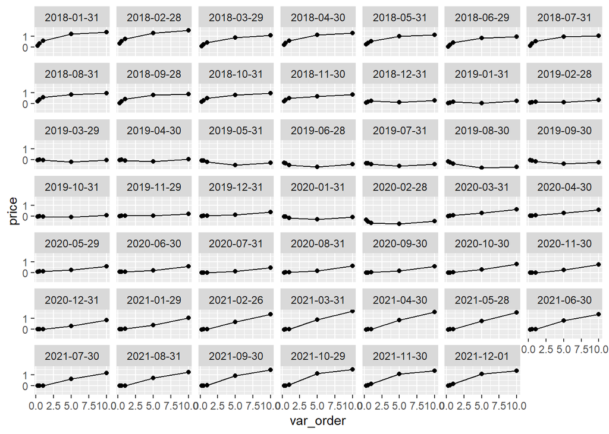

```r
# ## make plot at each year
# df_plot <- df_yield_curve %>%
#   ## select date where all data available
#   group_by(date) %>%
#   mutate(non_empty = sum(!is.na(price))) %>%
#   ungroup() %>%
#   filter(non_empty == 5) %>%
#   ## select the last date in a year, where all data available
#   group_by(symbol, year(date)) %>%
#   filter(row_number() == n()) %>%
#   ungroup() %>%
#   filter(
#     # date == "2021-11-18",
#     date >= "2010-01-01",
#     # month(date) == 12,
#     ) %>%
#   mutate(
#     var_order = case_when(
#       symbol == "T3MFF" ~ 3/12,
#       symbol == "T6MFF" ~ 6/12,
#       symbol == "T1YFF" ~ 1,
#       symbol == "T5YFF" ~ 5,
#       symbol == "T10YFF" ~ 10,
#     ))

## make plot at each end of month
df_plot <- df_yield_curve %>%
  ## select date where all data available
  group_by(date) %>%
  mutate(non_empty = sum(!is.na(price))) %>%
  ungroup() %>%
  filter(non_empty == 5) %>%
  ## select the last date in a year, where all data available
  group_by(symbol, year(date), month(date)) %>%
  filter(row_number() == n()) %>%
  ungroup() %>%
  ## filter by date
  filter(
    # date == "2021-11-18",
    date >= "2018-01-01",
    # month(date) == 12,
    ) %>%
  mutate(
    var_order = case_when(
      symbol == "T3MFF" ~ 3/12,
      symbol == "T6MFF" ~ 6/12,
      symbol == "T1YFF" ~ 1,
      symbol == "T5YFF" ~ 5,
      symbol == "T10YFF" ~ 10,
    ))

## plot
df_plot %>%
  ggplot(aes(x = var_order, y = price)) +
  geom_point() +
  geom_line() +
  facet_wrap(facets = vars(date))
```

The code below will run PCA on the Treasury yield curve.

```r
df_PCA <- df_yield_curve %>%
  select(symbol, date, price) %>%
  spread(key = symbol, value = price) %>%
  drop_na()

PCA_res <- prcomp(as.matrix(df_PCA %>% select(-c(date)) ),
       scale. = TRUE)

summary(PCA_res)
```

```
## Importance of components:
##                           PC1    PC2     PC3     PC4     PC5
## Standard deviation     1.9548 0.9470 0.50272 0.13801 0.10072
## Proportion of Variance 0.7643 0.1794 0.05055 0.00381 0.00203
## Cumulative Proportion  0.7643 0.9436 0.99416 0.99797 1.00000
```

```r
# PCA_res$sdev
PCA_res$rotation
```

```
##              PC1        PC2         PC3        PC4        PC5
## T10YFF 0.4217237 -0.5584748 -0.36877239  0.5313337  0.3032268
## T1YFF  0.4803388  0.1160690  0.63686768 -0.1447027  0.5738147
## T3MFF  0.4107220  0.5259022 -0.64455977 -0.3251365  0.1832029
## T5YFF  0.4499698 -0.4922012  0.04256838 -0.5768243 -0.4698157
## T6MFF  0.4693169  0.3947135  0.20282288  0.5082378 -0.5696491
```

```r
# PCA_res$center
# PCA_res$scale
# PCA_res$x

sum(PCA_res$rotation[,1]^2)
```

```
## [1] 1
```

```r
sum(PCA_res$rotation[,2]^2)
```

```
## [1] 1
```

- PC1 is related to general economy risk, all have the same direction. This reflects the shift in overall yield curve.
- PC2 related to the spread of short vs long term, i.e. long term = 10Y and 5Y, Short term = 1Y,6M,3M.
- The two PCs covers 94% variation of the data.

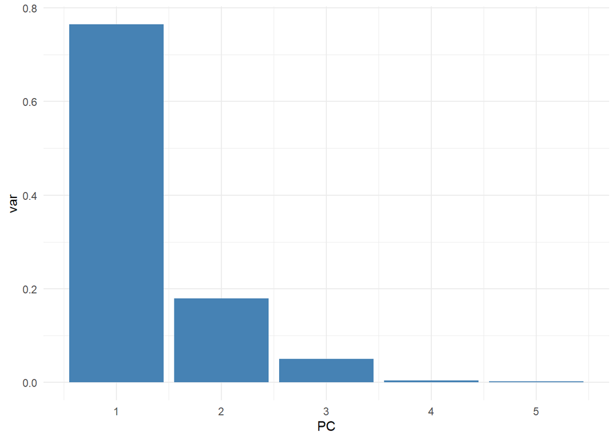

```r
# summary(PCA_res)
# PCA_res$sdev
# plot(PCA_res)

df_plot <- tibble(
  PC = 1:5,
  var = PCA_res$sdev^2/sum(PCA_res$sdev^2),
)

df_plot <- df_plot %>%
  mutate(cumsumvar = cumsum(var))

df_plot %>%
  ggplot(aes(x = PC, y = var)) +
  geom_bar(stat="identity", fill="steelblue")+
  theme_minimal()
```

- One advantage of PCA is “mutually exclusive”. PC1 and PC2 are uncorrelated.

```r
round(cor(PCA_res$x),2)
```

```
##     PC1 PC2 PC3 PC4 PC5
## PC1   1   0   0   0   0
## PC2   0   1   0   0   0
## PC3   0   0   1   0   0
## PC4   0   0   0   1   0
## PC5   0   0   0   0   1
```

```r
# PCA_res <- prcomp(mtcars, scale. = TRUE)
#
#
# mtcars %>%
#   summarise_all(.funs = list( ~ mean(.)) )
#
# mtcars %>%
#   summarise_all(.funs = list( ~ min(.)) )
#
# mtcars %>%
#   summarise_all(.funs = list( ~ max(.)) )
#
# PCA_res$sdev
# PCA_res$rotation
# PCA_res$center
# PCA_res$scale
# PCA_res$x
#
# summary(PCA_res)
#
```

# 3 Example of PCA on simulated data of yield curve

The example in previous section shows that the data generating process of yield curve has two main component. The first component is related to the general shift, i.e. upward or downward shift, of yield curve. The second component is the difference between short and long term rate. Most of the time, all else equal, longer maturity assets have higher risk and rate. However, during recession, short term uncertainty increases, while in the long term there are higher chance that the uncertainty will be resolved. Thus, when the market expects that there is upcoming recessions, the yield curve may be inverted.

The code below suggest that the data generation process of the yield curve are driven by PC1 and PC2.

```r
## generate unobservable data
set.seed(1)
# Y is unobservable matrix, contains PC1 and PC2
Y1 <- rnorm(n = nrow(df_PCA), mean = 0, sd = 2)
Y2 <- rnorm(n = nrow(df_PCA), mean = 0, sd = 1)

Y <- as.matrix(data.frame(Y1, Y2))

# Tmat is transformation matrix. Transform Y into X, where X is observed data.
# Tmat <- t(PCA_res$rotation[,1:2])
Tmat <- matrix(data = c(0.4, 0.4, 0.4, 0.4, 0.4,
                        0.5, 0.4, 0.1, -0.5, -0.6),
               nrow = 2,
               ncol = 5,
               byrow = TRUE)

colnames(Tmat) <- c("0.25", "0.5", "1", "5", "10")
rownames(Tmat) <- c("PC1", "PC2")

# X is observed data. X is a function of Y.
X <- Y %*% Tmat

# Run PCA
df_check <- prcomp(X)
df_check$sdev
```

```
## [1] 1.811848e+00 1.004649e+00 7.640117e-15 5.352173e-15 7.302246e-17
```

```r
summary(df_check)
```

```
## Importance of components:
##                           PC1    PC2      PC3       PC4       PC5
## Standard deviation     1.8118 1.0046 7.64e-15 5.352e-15 7.302e-17
## Proportion of Variance 0.7648 0.2352 0.00e+00 0.000e+00 0.000e+00
## Cumulative Proportion  0.7648 1.0000 1.00e+00 1.000e+00 1.000e+00
```